# Biometry-08

John Reddy Peasari

## Setting working directory

```r
dir <- getwd()
setwd(dir)
```

## Question 1

A marine biologist is interested on how the protein level in the diets of sea urchins affects growth. He maintained urchins in diets that were either low or high in protein content, as well as those individuals that occurred in the wild (reference). He randomly assigned 24 individuals, all the same age, to each of the three treatments. After three months he measured the suture length (IV) and suture width (SUTW) to determine growth. Perform a single linear regression for each individual treatment. What can you conclude about the diets in relation to growth?

## Looking at the complete dataset at once

```r
all.diet = read.csv("All_Diet.csv")
```

After, loading the dataset it can be observed that, there are three columns (DIET,IV and STUW). DIET coulmn has catogorical values and rest two comulms are numerical. For simplicity purpose, I have divided the dataset into 3 parts, based on the DIET treatment and performed statistical test individually.

## Ho: Suture length (IV) and suture width (SUTW) are not correlated and there is no effect by the consumption protein content in diet on the growth of Sea Urchins

## Ha: Suture length (IV) and suture width (SUTW) are correlated and there is an effect by the consumption of protein content diet on the growth of Sea Urchins

# In order to determine the realtionship between Suture length (IV) and suture width (SUTW) in Sea Urchins, the most appropriate statistical test is the linear refression.

```r
cor(all.diet[,2:3])
```

```
##             IV      SUTW
## IV   1.0000000 0.3461423
## SUTW 0.3461423 1.0000000
```

```r
cor.test(all.diet$IV, all.diet$SUTW, method = "spearman")
```

```
##
##  Spearman's rank correlation rho
##
## data:  all.diet$IV and all.diet$SUTW
## S = 37321, p-value = 5e-04
## alternative hypothesis: true rho is not equal to 0
## sample estimates:
##       rho
## 0.3999448
```

It can seen that, Suture length (IV) vs Suture width (SUTW) are poitively correlated having a Pearson’s product moment value of 0.3461423. Similarly, pearman’s rank correlation gave p value of 5e-04 and rho 0.3999448 indicating positive correlation between them.

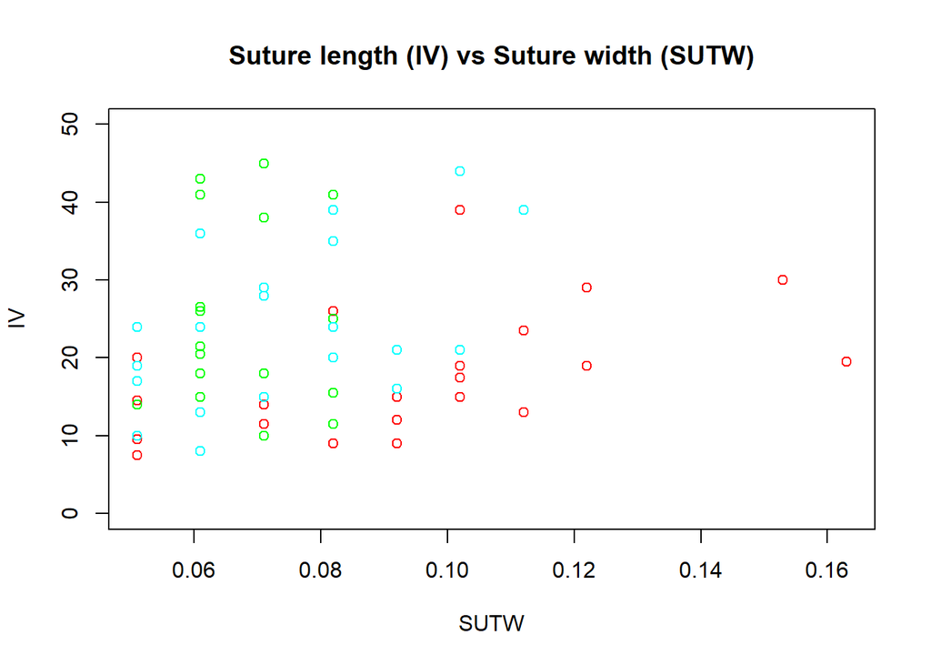

```r
plot(high.diet$IV ~ high.diet$SUTW, col = "red", ylim = c(0,50), xlab="SUTW",ylab="IV",
     main = "Suture length (IV) vs Suture width (SUTW)")
points(low.diet$IV ~ low.diet$SUTW, col = "green")
points(reference.diet$IV ~ reference.diet$SUTW, col = "cyan")
```

Looking the the combined plot of high, it can be observed that in all the three diets length and width are increasing positively and might have a correlation between IV and SUTW. This inference can be tested by suitble statistical test further.

## Performing regression on High Diet

```r
high.diet = read.csv("High_Diet.csv")
```

```r
cor(high.diet[,2:3])
```

```
##             IV      SUTW
## IV   1.0000000 0.5099979
## SUTW 0.5099979 1.0000000
```

```r
# Determine significance of our correlation
cor.test(high.diet$IV, high.diet$SUTW, method = "spearman")
```

```
##
##  Spearman's rank correlation rho
##
## data:  high.diet$IV and high.diet$SUTW
## S = 1022.7, p-value = 0.004845
## alternative hypothesis: true rho is not equal to 0
## sample estimates:
##       rho
## 0.5553533
```

```r
cor.test(high.diet$IV, high.diet$SUTW, method = "kendall")
```

```
##
##  Kendall's rank correlation tau
##
## data:  high.diet$IV and high.diet$SUTW
## z = 2.7629, p-value = 0.005729
## alternative hypothesis: true tau is not equal to 0
## sample estimates:
##       tau
## 0.4217656
```

```r
high.diet.lm <- lm(high.diet$IV ~ high.diet$SUTW)
summary(high.diet.lm)
```

```
##
## Call:
## lm(formula = high.diet$IV ~ high.diet$SUTW)
##
## Residuals:
##    Min     1Q Median     3Q    Max
## -8.479 -4.010 -1.042  2.491 20.270
##
## Coefficients:
##                Estimate Std. Error t value Pr(>|t|)
## (Intercept)       5.975      4.294   1.392   0.1779
## high.diet$SUTW  125.045     44.965   2.781   0.0109 *
## ---
## Signif. codes:  0 '***' 0.001 '**' 0.01 '*' 0.05 '.' 0.1 ' ' 1
##
## Residual standard error: 6.708 on 22 degrees of freedom
## Multiple R-squared:  0.2601, Adjusted R-squared:  0.2265
## F-statistic: 7.734 on 1 and 22 DF,  p-value: 0.0109
```

```r
# Displaying  and Confidence Intervals
high.diet.pred.dataframe <- data.frame(SUTW)
pp <- predict(high.diet.lm,int="p",newdata=high.diet.pred.dataframe)
pc <- predict(high.diet.lm,int="c",newdata=high.diet.pred.dataframe)
```

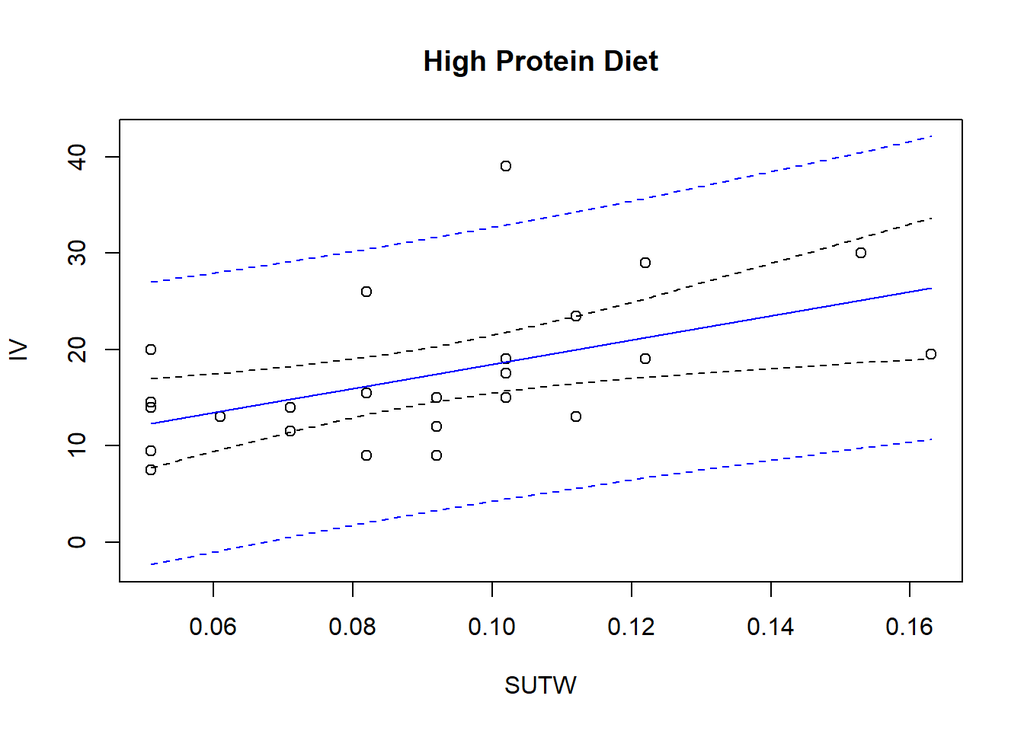

```r
# create prediction and confidence intervals from evenly spaced x-axis values
plot(IV ~ SUTW, main = "High Protein Diet",ylim = range(IV,pp))
pred.SUTW <- high.diet.pred.dataframe$SUTW
matlines(pred.SUTW, pc,lty=c(1,2,2),col = "black")
matlines(pred.SUTW, pp,lty=c(1,2,2),col = "blue")
```

## Result 1:

After performing correlation test and regression test for the high protein diet alone, it can be inferred that the slope is having a value of 125.045 with intercept 5.975 and t value (t test)of 2.781.I can be noticed that the slope is significantly diferent from zero with a proability value of 0.0109. Hence, we fail to accept the NULL hypothesis. Linear refression generated multiple R-squared value of 0.2601, which illustrated that there might be little tight correlation between suture length (IV) and suture width (SUTW). Aslo, correlation tests ( “spearman”, “kendall” ) displayed a positive correlations of 0.5553533 and 0.4217656 along with significant p- values (0.004845 and 0.005729). Therefore, we fail to accept the NULL hypothesis and say that suture length (IV) and suture width (SUTW) are correlated in sea urchins with reference to the high protein content diet.

## Performing regression on Low Diet

```r
low.diet = read.csv("Low_Diet.csv")
```

```r
cor(low.diet[,2:3])
```

```
##             IV      SUTW
## IV   1.0000000 0.4303512
## SUTW 0.4303512 1.0000000
```

```r
# Determine significance of our correlation
cor.test(low.diet$IV, low.diet$SUTW, method = "spearman")
```

```
##
##  Spearman's rank correlation rho
##
## data:  low.diet$IV and low.diet$SUTW
## S = 1351.6, p-value = 0.04526
## alternative hypothesis: true rho is not equal to 0
## sample estimates:
##       rho
## 0.4123286
```

```r
cor.test(low.diet$IV, low.diet$SUTW, method = "kendall")
```

```
##
##  Kendall's rank correlation tau
##
## data:  low.diet$IV and low.diet$SUTW
## z = 2.0386, p-value = 0.04149
## alternative hypothesis: true tau is not equal to 0
## sample estimates:
##       tau
## 0.3228095
```

```r
low.diet.lm <- lm(low.diet$IV ~ low.diet$SUTW)
summary(low.diet.lm)
```

```
##
## Call:
## lm(formula = low.diet$IV ~ low.diet$SUTW)
##
## Residuals:
##     Min      1Q  Median      3Q     Max
## -17.382  -6.995  -2.701   4.988  20.979
##
## Coefficients:
##               Estimate Std. Error t value Pr(>|t|)
## (Intercept)      2.091      9.036   0.231   0.8192
## low.diet$SUTW  326.719    146.105   2.236   0.0358 *
## ---
## Signif. codes:  0 '***' 0.001 '**' 0.01 '*' 0.05 '.' 0.1 ' ' 1
##
## Residual standard error: 10.97 on 22 degrees of freedom
## Multiple R-squared:  0.1852, Adjusted R-squared:  0.1482
## F-statistic: 5.001 on 1 and 22 DF,  p-value: 0.0358
```

[figure not shown]

```r
# Displaying  and Confidence Intervals
low.diet.pred.dataframe <- data.frame(SUTW)
pp <- predict(low.diet.lm,int="p",newdata=low.diet.pred.dataframe)
pc <- predict(low.diet.lm,int="c",newdata=low.diet.pred.dataframe)

# create prediction and confidence intervals from evenly spaced x-axis values
plot(IV ~ SUTW, main = "Low Protein Diet",ylim = range(IV,pp))
pred.SUTW <- low.diet.pred.dataframe$SUTW
matlines(pred.SUTW, pc,lty=c(1,3,2),col = "black")
matlines(pred.SUTW, pp,lty=c(1,2,2),col = "blue")
```